## Introduction

This assignment makes use of data from a personal activity monitoring device. This device collects data at 5 minute intervals through out the day. The data consists of two months of data from an anonymous individual collected during the months of October and November, 2012 and include the number of steps taken in 5 minute intervals each day.

The dataset is stored in a comma-separated-value (CSV) file and there are a total of 17,568 observations in this dataset.

The variables included in this dataset are:

- **steps**: Number of steps taking in a 5-minute interval (missing values are coded as `NA`)
- **date**: The date on which the measurement was taken in YYYY-MM-DD format
- **interval**: Identifier for the 5-minute interval in which measurement was taken

### Loading and preprocessing the data

```r
activit<-read.csv("activity.csv")

activit$date<-as.Date(paste(activit$date))
sum<-tapply(activit$steps,activit$date,sum)
sum1<-as.data.frame(sum)
```

### Histogram of the total number of steps taken each day

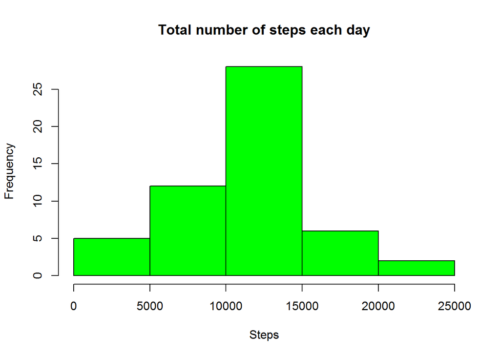

```r
hist(sum1$sum,col="GREEN",xlab="Steps",ylab="Frequency",main="Total number of steps each day")
```

### Mean and Median of number of steps taken per day

```r
mean(as.numeric(sum1$sum),na.rm=TRUE)
```

```
## [1] 10766.19
```

```r
median(as.numeric(sum1$sum),na.rm=TRUE)
```

```
## [1] 10765
```

### Time series plot (i.e. `type = "l"`) of the 5-minute interval (x-axis) and the average number of steps taken, averaged across all days (y-axis)

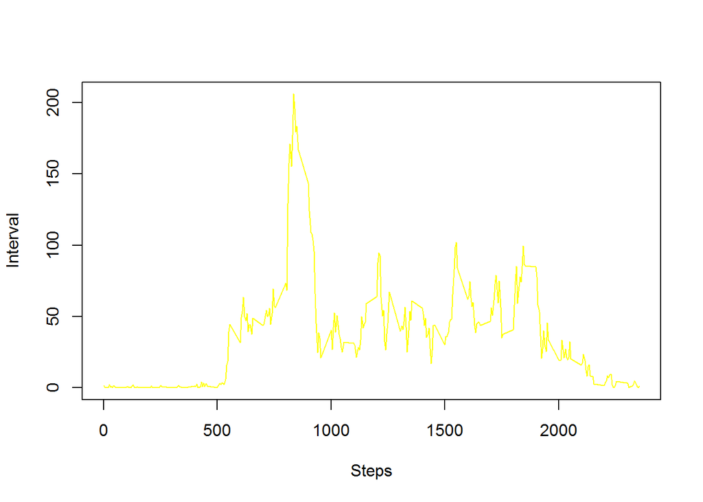

```r
##preparation of the data
new<-as.data.frame(tapply(activit$steps,activit$interval,mean,na.rm=TRUE))
new$interval<-as.numeric(row.names(new))
new1<-data.frame(interval=new$interval,steps=new$`tapply(activit$steps, activit$interval, mean, na.rm = TRUE)`)

##plot
plot(new1$interval,new1$steps,type="l",col=215,xlab ="Steps",ylab="Interval")
```

### Calculation of 5-minute interval, on average across all the days in the dataset, containing the maximum number of steps.

```r
max(new1$steps,na.rm=TRUE)
```

```
## [1] 206.1698
```

```r
##max value of steps is 206.1698 in interval 835
```

### Total number of missing values in the dataset (i.e. the total number of rows with `NA`s)

```r
a<-complete.cases(activit)
sum(!a)
```

```
## [1] 2304
```

### Replacing all the na’s with the mean in new dataset

```r
activity<-activit
activity$steps=ifelse(is.na(activit$steps)==TRUE,mean(activit$steps,na.rm=TRUE),activit$steps)
sum2<-tapply(activity$steps,activity$date,sum)
sum3<-as.data.frame(sum2)
```

### Histogram of the total number of steps taken each day

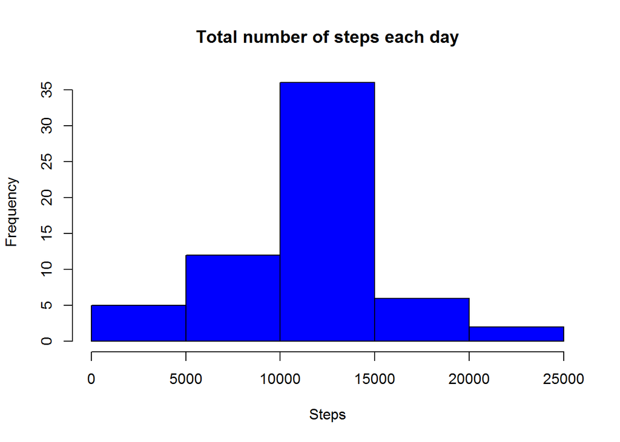

```r
hist(sum3$sum2,col="BLUE",xlab="Steps",ylab="Frequency",main="Total number of steps each day")
```

### Comparing new mean and median with old dataset mean and median

```r
mean(sum3$sum2)
```

```
## [1] 10766.19
```

```r
median(sum3$sum2)
```

```
## [1] 10766.19
```

```r
####There is only change in median
```

### A new factor variable in the dataset with two levels – “weekday” and “weekend” indicating whether a given date is a weekday or weekend day.

```r
library(dplyr)
activity$date<-as.Date(activity$date)
activity$days<-ifelse(weekdays(activity$date)== "Monday"|weekdays(activity$date)== "Tuesday"|
                              weekdays(activity$date)== "Wednesday"|weekdays(activity$date)== "Thursday"|
                              weekdays(activity$date)== "Friday","weekdays","weekends")
gnew <- activity %>% group_by(interval, days) %>% summarise(steps = mean(steps))
```

### A panel plot containing a time series plot (i.e. `type = "l"`) of the 5-minute interval (x-axis) and the average number of steps taken, averaged across all weekday days or weekend days (y-axis).

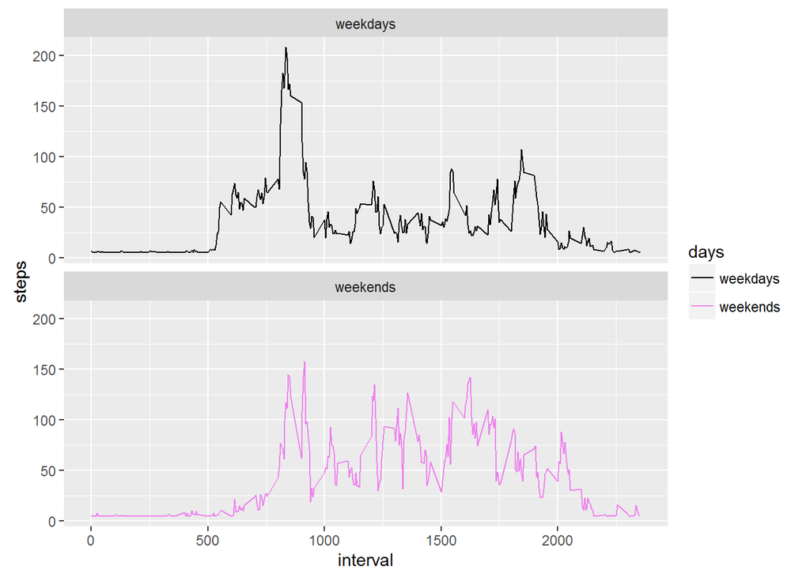

```r
library(ggplot2)
final <- ggplot(gnew, aes(x=interval, y=steps, color = days)) +
        geom_line() +
        facet_wrap(~days, ncol = 1, nrow=2)+scale_color_manual(values = c("black", "violet"))
print(final)
```